# Clean Waters — Nearshore Chl-a and ratio excess

OHI GoC 2025

June 24, 2026

# Overview

## Goal

Use satellite **chlorophyll-a (Chl-a)** to identify **nearshore** areas where coastal productivity is elevated relative to what we expect from **regional offshore** waters — a possible signal of nutrient enrichment from land.

## Data

- **Source:** Copernicus GlobColour, 4 km, monthly (prepped in `step1_cw_chla.qmd`)
- **Path:** `/home/shares/ohi/OHI_GOC/goal_prep/cw/v2025/chla_int/monthly_rasters/`
- **Years:** 2000–2024 (skip 1997 and partial 2025)
- **Units:** mg/m³

## Chosen method: ratio-adjusted excess

Raw nearshore Chl-a and offshore Chl-a **rise and fall together** (shared upwelling and climate). Simple subtraction (`near − off`) does not remove those shared spikes because coastal Chl-a usually increases **more in mg/m³** than offshore.

Instead we assume the usual oceanographic link within each OHI region is **multiplicative**:

$$\text{near}_{r,t} \approx R_r \times \text{off}_{r,t}$$

We estimate a reference ratio $R_{\text{ref},r}$ from the **full analysis period (2000–2024)**, then define **ratio excess**:

$$\textbf{ratio\_excess}_{r,t} = \text{near}_{r,t} - R_{\text{ref},r} \times \text{off}_{r,t}$$

- **≈ 0:** nearshore is at its usual level relative to offshore that year
- **> 0:** coastal–offshore gap is **wider than normal** (candidate enrichment signal)
- **Increasing over time:** widening coastal gradient (our primary trend metric)

**Spatial scope:** 15 km nearshore band vs offshore (> 15 km) within each of 9 marine OHI regions.

# Setup

```r
library(terra)
library(sf)
library(here)
library(dplyr)
library(tidyr)
library(purrr)
library(ggplot2)

# Paths
chla_int_dir <- "/home/shares/ohi/OHI_GOC/goal_prep/cw/v2025/chla_int"
chl_dir      <- file.path(chla_int_dir, "monthly_rasters")

ohi_rgns_shp   <- here("spatial/ohi_regions/goc_ohi_rgns.shp")
coastline_shp  <- "/home/shares/ohi/OHI_GOC/spatial/ne_10m_coastline/ne_10m_coastline.shp"
rgn_core       <- read.csv(here("spatial/ohi_regions/ohi_rgns_core.csv")) %>%
  filter(location == "marine")

# Analysis settings
year_start     <- 2000L
year_end       <- 2024L
years          <- seq(year_start, year_end)
ref_year_start <- year_start
ref_year_end   <- year_end
ref_period_lbl <- sprintf("%d–%d", ref_year_start, ref_year_end)
buffer_crs     <- 6372L

# Paths scoped to nearshore band width (keeps 15 km outputs separate)
dir_masks     <- file.path(chla_int_dir, "masks", nearshore_tag)
dir_ratio     <- file.path(chla_int_dir, paste0("ratio_excess_", nearshore_tag), "annual")
dir_ratio_ref <- file.path(chla_int_dir, paste0("ratio_excess_", nearshore_tag), "reference")

purrr::walk(c(dir_masks, dir_ratio, dir_ratio_ref), dir.create,
            showWarnings = FALSE, recursive = TRUE)

# Plot labels (depend on nearshore_km)
near_lbl <- sprintf("Nearshore Chl-a (%d km)", nearshore_km)
off_lbl  <- sprintf("Offshore Chl-a (>%d km)", nearshore_km)

# Years flagged as "early period" for trend sensitivity checks
early_period_end <- 2004L
trend_sensitivity_starts <- c(2000L, 2005L, 2011L)

# Colors shared by gulf-wide and per-region comparison plots
metric_colors <- c(
  near_lbl = "#1a9850",
  off_lbl = "#41b6c4",
  "Raw contrast (near − off)" = "#756bb1",
  "Ratio excess (near − R_ref × off)" = "#e66101"
)
names(metric_colors)[1:2] <- c(near_lbl, off_lbl)

# Gulf-wide plot (5.1) uses three metrics only — no raw contrast
gulf_metric_colors <- metric_colors[c(near_lbl, off_lbl, "Ratio excess (near − R_ref × off)")]

# Major ENSO years for vertical markers (informal; not formal ONI classification)
enso_events <- tibble::tribble(
  ~year, ~label,    ~phase,
  1998,  "El Niño", "el_nino",
  1999,  "La Niña", "la_nina",
  2010,  "El Niño", "el_nino",
  2011,  "La Niña", "la_nina",
  2015,  "El Niño", "el_nino",
  2016,  "El Niño", "el_nino",
  2020,  "La Niña", "la_nina",
  2022,  "La Niña", "la_nina",
  2023,  "El Niño", "el_nino",
  2024,  "El Niño", "el_nino"
) %>%
  filter(year >= year_start, year <= year_end)
```

```r
# Annual mean Chl-a raster for one calendar year
annual_mean_chl <- function(yr, files) {
  mean(rast(files[grepl(sprintf("/%s-", yr), files)]))
}

# Apply a zonal summary table back onto the region-id grid
expand_zonal_to_raster <- function(zonal_df, zone_rast, value_col = 2) {
  zonal_df <- zonal_df[!is.na(zonal_df[[value_col]]), , drop = FALSE]
  subst(zone_rast, zonal_df[[1]], zonal_df[[value_col]])
}

# Ratio excess raster: each nearshore cell minus R_ref * regional offshore mean
compute_ratio_excess_raster <- function(yr_mean, nearshore_bin, offshore_mask,
                                        rgn_id_num, r_ref_df) {
  off_z <- zonal(yr_mean * offshore_mask, rgn_id_num, fun = mean, na.rm = TRUE)
  colnames(off_z) <- c("rgn_num", "off_mean")
  off_r <- expand_zonal_to_raster(off_z, rgn_id_num)
  r_ref_r <- expand_zonal_to_raster(
    r_ref_df %>% select(rgn_num, R_ref) %>% as.data.frame(), rgn_id_num
  )
  ifel(nearshore_bin == 1, yr_mean - r_ref_r * off_r, NA)
}

# Long format for four-line per-region comparison plots (5.2)
prep_comparison_long <- function(df) {
  df %>%
    pivot_longer(c(near, off, raw_contrast, ratio_excess),
                 names_to = "metric", values_to = "value") %>%
    mutate(metric = recode(metric,
      near = near_lbl,
      off = off_lbl,
      raw_contrast = "Raw contrast (near − off)",
      ratio_excess = "Ratio excess (near − R_ref × off)"
    ))
}

# Long format for gulf-wide plot (5.1): nearshore, offshore, ratio excess only
prep_gulf_comparison_long <- function(df) {
  df %>%
    pivot_longer(c(near, off, ratio_excess),
                 names_to = "metric", values_to = "value") %>%
    mutate(metric = recode(metric,
      near = near_lbl,
      off = off_lbl,
      ratio_excess = "Ratio excess (near − R_ref × off)"
    ))
}
```

# Step 1 — Load Chl-a data

```r
chl_files <- list.files(chl_dir, pattern = "\\.tif$", full.names = TRUE)
chl_files <- chl_files[!grepl("/1997-|/2025-", chl_files)]

cat("Monthly rasters:", length(chl_files), "\n")
```

```
## Monthly rasters: 324
```

```r
cat("From", basename(chl_files[1]), "to", basename(chl_files[length(chl_files)]), "\n")
```

```
## From 1998-01-01.tif to 2024-12-01.tif
```

```r
chl_template <- rast(chl_files[grepl("/2020-06", chl_files)])
```

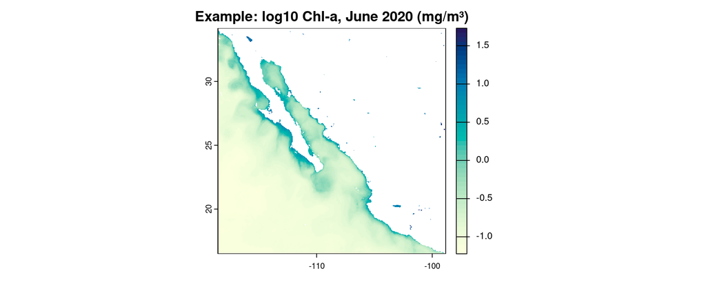

```r
plot(
  log10(chl_template + 0.01),
  main = "Example: log10 Chl-a, June 2020 (mg/m³)",
  col = hcl.colors(50, "YlGnBu", rev = TRUE)
)
```

# Step 2 — Nearshore and offshore zones

Within each marine OHI region we define:

1. **Nearshore** — marine pixels within **15 km** of the coast
2. **Offshore** — marine pixels **farther than 15 km** from the coast

Offshore mean Chl-a in each region is the **oceanographic reference** for that region and year.

```r
marine_sf <- st_read(ohi_rgns_shp, quiet = TRUE) %>% filter(location == "marine")
marine_vect <- vect(st_transform(marine_sf, crs(chl_template)))
marine_raw  <- rasterize(marine_vect, chl_template, field = 1)
rgn_id_num  <- rasterize(marine_vect, chl_template, field = "id")

coast_goc <- st_read(coastline_shp, quiet = TRUE) %>%
  st_make_valid() %>%
  st_intersection(st_as_sfc(st_bbox(chl_template)) %>% st_set_crs(crs(chl_template)))

nearshore_poly <- coast_goc %>%
  st_transform(buffer_crs) %>% st_union() %>%
  st_buffer(nearshore_km * 1000) %>%
  st_intersection(st_make_valid(st_union(st_transform(marine_sf, buffer_crs))))

nearshore_raw <- rasterize(vect(st_transform(nearshore_poly, crs(chl_template))),
                           chl_template, field = 1)

# Binary 0/1 masks (required — terra uses NaN outside polygons)
marine_bin    <- subst(marine_raw, 1, 1, others = 0)
nearshore_bin <- subst(nearshore_raw, 1, 1, others = 0)
nearshore_mask <- ifel(nearshore_bin == 1, 1, NA)
offshore_mask  <- ifel(marine_bin == 1, ifel(nearshore_bin == 1, NA, 1), NA)

stopifnot(
  sum(values(nearshore_bin) == 1) + sum(values(offshore_mask) == 1, na.rm = TRUE) ==
    sum(values(marine_bin) == 1)
)

writeRaster(nearshore_mask, file.path(dir_masks, sprintf("nearshore_%s.tif", nearshore_tag)), overwrite = TRUE)
writeRaster(offshore_mask,  file.path(dir_masks, sprintf("offshore_%s.tif", nearshore_tag)), overwrite = TRUE)
writeRaster(rgn_id_num,     file.path(dir_masks, "rgn_id_num.tif"), overwrite = TRUE)

cat("Nearshore cells:", sum(values(nearshore_bin) == 1), "\n")
```

```
## Nearshore cells: 3442
```

```r
cat("Offshore cells: ", sum(values(offshore_mask) == 1, na.rm = TRUE), "\n")
```

```
## Offshore cells:  9781
```

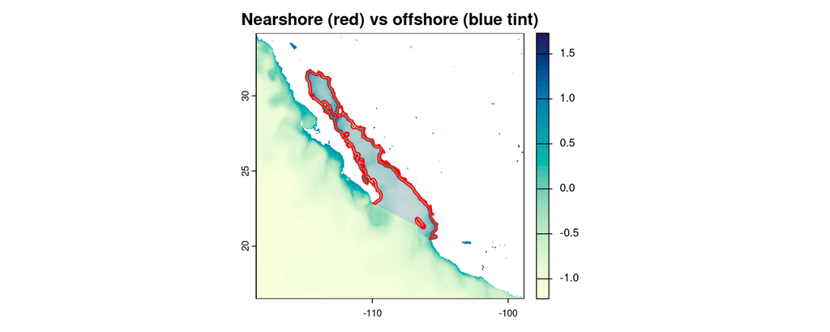

```r
plot(log10(chl_template + 0.01), main = "Nearshore (red) vs offshore (blue tint)",
     col = hcl.colors(50, "YlGnBu", rev = TRUE))
plot(st_geometry(st_transform(nearshore_poly, crs(chl_template))), add = TRUE, border = "red", lwd = 1.5)
plot(ifel(offshore_mask == 1, 1, NA), add = TRUE, col = rgb(0, 0, 1, 0.12), legend = FALSE)
```

# Step 3 — Regional annual nearshore and offshore Chl-a

For each **year** and **OHI region**, compute mean Chl-a in the nearshore and offshore bands.

```r
regional_annual <- map_dfr(years, function(yr) {
  yr_mean <- annual_mean_chl(yr, chl_files)
  near_z <- zonal(yr_mean * nearshore_mask, rgn_id_num, fun = mean, na.rm = TRUE)
  off_z  <- zonal(yr_mean * offshore_mask,  rgn_id_num, fun = mean, na.rm = TRUE)
  near_z %>%
    rename(rgn_num = 1, near = 2) %>%
    left_join(off_z %>% rename(rgn_num = 1, off = 2), by = "rgn_num") %>%
    left_join(rgn_core, by = c("rgn_num" = "id")) %>%
    mutate(year = yr, raw_contrast = near - off)
})

regional_annual %>% select(rgn_id, year, near, off, raw_contrast) %>% head(12)
```

```
##      rgn_id year     near       off raw_contrast
## 1  Region_1 2000 1.934180 1.8453048   0.08887567
## 2  Region_2 2000 1.765534 1.0744617   0.69107248
## 3  Region_3 2000 1.729880 0.8827352   0.84714495
## 4  Region_4 2000 1.055863 0.5089880   0.54687523
## 5  Region_5 2000 1.888781 1.4836096   0.40517171
## 6  Region_6 2000 2.039767 1.2262533   0.81351346
## 7  Region_7 2000 2.515995 1.0377983   1.47819718
## 8  Region_8 2000 3.578984 1.3507583   2.22822598
## 9  Region_9 2000 4.772892 2.1517242   2.62116751
## 10 Region_1 2001 2.327506 1.9589537   0.36855204
## 11 Region_2 2001 1.965393 1.3795907   0.58580275
## 12 Region_3 2001 1.617860 0.7680813   0.84977898
```

## Why raw contrast is not enough

Nearshore and offshore Chl-a **track each other** year to year. Raw contrast (`near − off`) still spikes in high-productivity years because nearshore rises **more in mg/m³** than offshore.

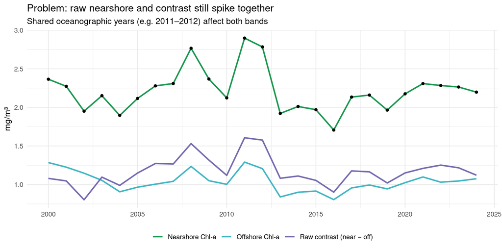

```r
gulf_raw <- regional_annual %>%
  group_by(year) %>%
  summarize(near = mean(near), off = mean(off), contrast = mean(raw_contrast),
            .groups = "drop")

ggplot(gulf_raw, aes(year)) +
  geom_line(aes(y = near, color = "Nearshore Chl-a"), linewidth = 1) +
  geom_line(aes(y = off, color = "Offshore Chl-a"), linewidth = 1) +
  geom_line(aes(y = contrast, color = "Raw contrast (near − off)"), linewidth = 1) +
  geom_point(aes(y = near), size = 1.5) +
  scale_color_manual(name = NULL, values = c("#1a9850", "#41b6c4", "#756bb1")) +
  labs(
    title = "Problem: raw nearshore and contrast still spike together",
    subtitle = "Shared oceanographic years (e.g. 2011–2012) affect both bands",
    x = NULL, y = "mg/m³"
  ) +
  theme_minimal(base_size = 12) +
  theme(legend.position = "bottom")
```

# Step 4 — Ratio excess (method)

## 4.1 Reference ratio by region

Over the **full analysis period (2000–2024)**, for each region:

$$R_{\text{ref},r} = \text{mean}\left(\frac{\text{near}_{r,t}}{\text{off}_{r,t}}\right)$$

```r
r_ref <- regional_annual %>%
  filter(year >= ref_year_start, year <= ref_year_end) %>%
  group_by(rgn_num, rgn_id) %>%
  summarize(R_ref = mean(near / off, na.rm = TRUE), .groups = "drop")

r_ref_file <- sprintf("R_ref_near_off_ratio_%d_%d.csv", ref_year_start, ref_year_end)
write.csv(r_ref, file.path(dir_ratio_ref, r_ref_file), row.names = FALSE)

knitr::kable(
  r_ref, digits = 2,
  caption = sprintf("Reference nearshore:offshore Chl-a ratio (%s)", ref_period_lbl)
)
```

Reference nearshore:offshore Chl-a ratio (2000–2024)

| rgn_num | rgn_id | R_ref |
| --- | --- | --- |
| 1 | Region_1 | 1.01 |
| 2 | Region_2 | 1.72 |
| 3 | Region_3 | 2.42 |
| 4 | Region_4 | 2.39 |
| 5 | Region_5 | 1.31 |
| 6 | Region_6 | 2.10 |
| 7 | Region_7 | 3.22 |
| 8 | Region_8 | 3.88 |
| 9 | Region_9 | 3.46 |

## 4.2 Compute ratio excess each year

```r
regional_ratio <- regional_annual %>%
  left_join(r_ref, by = c("rgn_num", "rgn_id")) %>%
  mutate(ratio_excess = near - R_ref * off)

regional_ratio %>%
  select(rgn_id, year, near, off, R_ref, ratio_excess) %>%
  head(12)
```

```
##      rgn_id year     near       off    R_ref ratio_excess
## 1  Region_1 2000 1.934180 1.8453048 1.011681   0.06732105
## 2  Region_2 2000 1.765534 1.0744617 1.722027  -0.08471751
## 3  Region_3 2000 1.729880 0.8827352 2.422742  -0.40875950
## 4  Region_4 2000 1.055863 0.5089880 2.394248  -0.16278039
## 5  Region_5 2000 1.888781 1.4836096 1.314416  -0.06129925
## 6  Region_6 2000 2.039767 1.2262533 2.104968  -0.54145745
## 7  Region_7 2000 2.515995 1.0377983 3.222818  -0.82863913
## 8  Region_8 2000 3.578984 1.3507583 3.876895  -1.65776450
## 9  Region_9 2000 4.772892 2.1517242 3.464884  -2.68258311
## 10 Region_1 2001 2.327506 1.9589537 1.011681   0.34566991
## 11 Region_2 2001 1.965393 1.3795907 1.722027  -0.41029852
## 12 Region_3 2001 1.617860 0.7680813 2.422742  -0.24300256
```

## 4.3 Save cell-level ratio excess rasters

At each nearshore pixel in region $r$:

$$\text{excess}_{i,t} = \text{Chl}_{i,t} - R_{\text{ref},r} \times \bar{O}_{r,t}$$

```r
for (yr in years) {
  re <- compute_ratio_excess_raster(
    annual_mean_chl(yr, chl_files), nearshore_bin, offshore_mask,
    rgn_id_num, r_ref
  )
  writeRaster(re, file.path(dir_ratio, sprintf("ratio_excess_%s.tif", yr)),
              overwrite = TRUE)
}
cat("Saved", length(years), "ratio excess rasters to:", dir_ratio, "\n")
```

```
## Saved 25 ratio excess rasters to: /home/shares/ohi/OHI_GOC/goal_prep/cw/v2025/chla_int/ratio_excess_15km/annual
```

# Step 5 — Results

## 5.1 Gulf-wide time series

Average across regions each year. **Ratio excess** (orange) stays much flatter than raw contrast on shared spike years. Vertical lines mark major ENSO years (informal markers — see `enso_events` in Parameters).

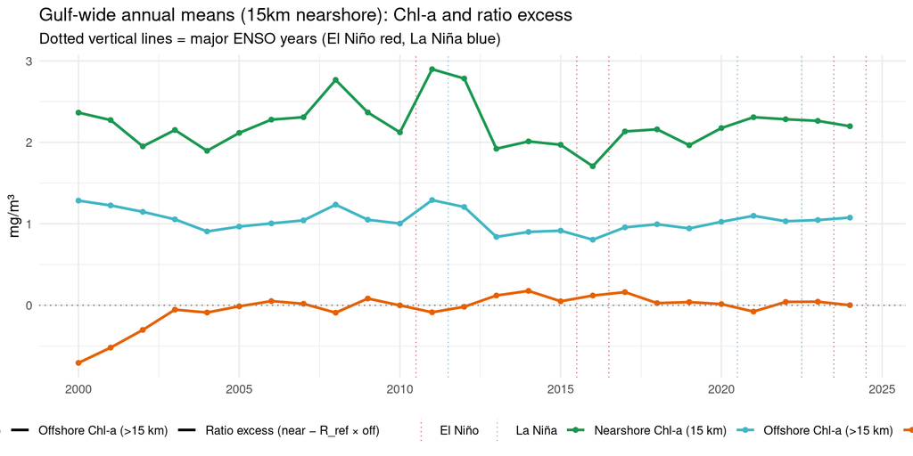

```r
gulf_summary <- regional_ratio %>%
  group_by(year) %>%
  summarize(
    near = mean(near),
    off = mean(off),
    ratio_excess = mean(ratio_excess),
    .groups = "drop"
  )

enso_lines <- enso_events %>%
  mutate(
    enso_phase = if_else(phase == "el_nino", "El Niño", "La Niña"),
    xintercept = year + 0.5
  )

gulf_plot_colors <- c(
  gulf_metric_colors,
  "El Niño" = "#B2182B",
  "La Niña" = "#4393C3"
)

ggplot(prep_gulf_comparison_long(gulf_summary), aes(year, value, color = metric, linetype = metric)) +
  geom_vline(
    data = enso_lines,
    aes(xintercept = xintercept, color = enso_phase),
    linewidth = 0.4,
    alpha = 0.7,
    linetype = "dotted",
    inherit.aes = FALSE
  ) +
  geom_line(linewidth = 1) +
  geom_point(size = 1.5) +
  geom_hline(yintercept = 0, linetype = "dotted", color = "gray50") +
  scale_color_manual(values = gulf_plot_colors) +
  scale_linetype_manual(
    values = stats::setNames(
      rep("solid", length(gulf_metric_colors)),
      names(gulf_metric_colors)
    )
  ) +
  labs(
    title = sprintf("Gulf-wide annual means (%s nearshore): Chl-a and ratio excess", nearshore_tag),
    subtitle = "Dotted vertical lines = major ENSO years (El Niño red, La Niña blue)",
    x = NULL, y = "mg/m³", color = NULL, linetype = NULL
  ) +
  theme_minimal(base_size = 12) +
  theme(legend.position = "bottom")
```

## 5.2 Per-region comparison plots (same format as gulf-wide)

Each panel shows **nearshore**, **offshore**, **raw contrast**, and **ratio excess** for one OHI region. Shaded band = early years (2000–2004) when ratio excess was often **negative** in several regions.

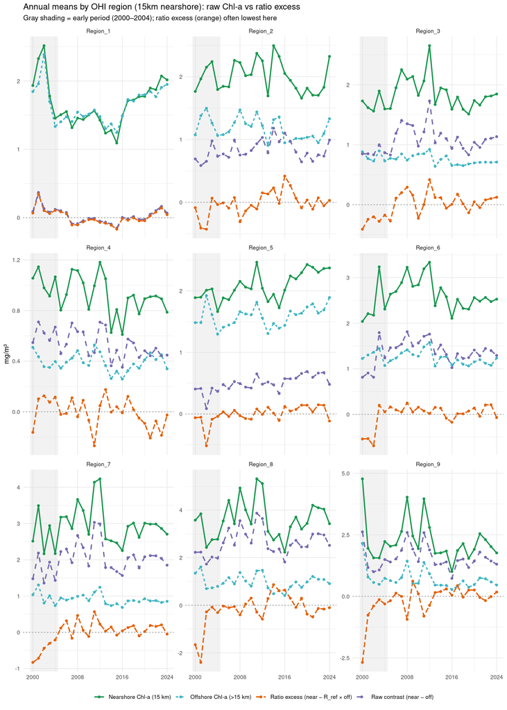

```r
regional_long <- prep_comparison_long(regional_ratio)

ggplot(regional_long, aes(year, value, color = metric, linetype = metric)) +
  annotate(
    "rect",
    xmin = year_start - 0.5, xmax = early_period_end + 0.5,
    ymin = -Inf, ymax = Inf,
    fill = "gray85", alpha = 0.35
  ) +
  geom_line(linewidth = 0.85) +
  geom_point(size = 1.2) +
  geom_hline(yintercept = 0, linetype = "dotted", color = "gray50") +
  facet_wrap(~ rgn_id, ncol = 3, scales = "free_y") +
  scale_color_manual(values = metric_colors) +
  scale_x_continuous(breaks = seq(2000, 2024, 8)) +
  labs(
    title = sprintf("Annual means by OHI region (%s nearshore): raw Chl-a vs ratio excess", nearshore_tag),
    subtitle = "Gray shading = early period (2000–2004); ratio excess (orange) often lowest here",
    x = NULL, y = "mg/m³", color = NULL, linetype = NULL
  ) +
  theme_minimal(base_size = 10) +
  theme(legend.position = "bottom")
```

## 5.3 Ratio excess only — early vs recent

Focus on ratio excess alone to see whether regions started **below zero** and rose toward or above zero in recent years.

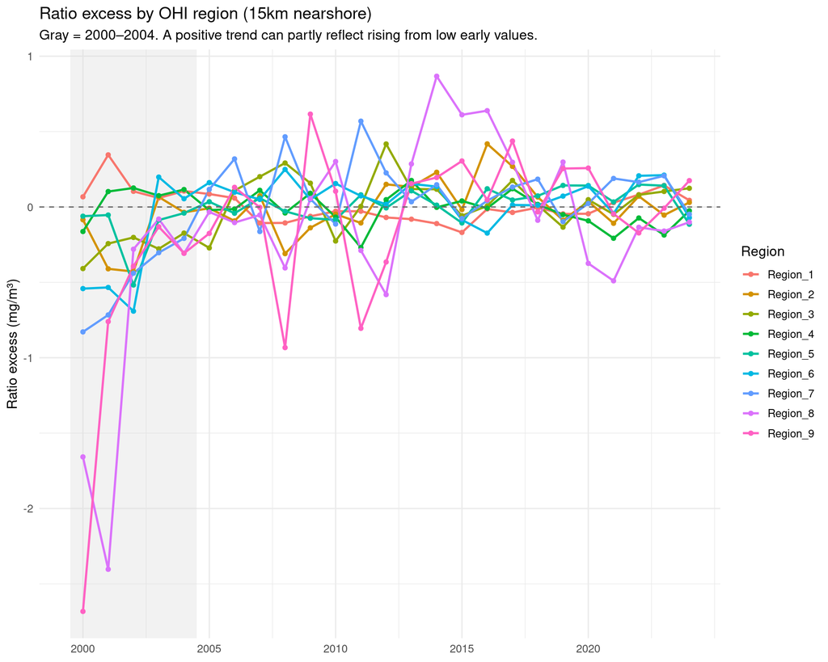

```r
ggplot(regional_ratio, aes(year, ratio_excess, color = rgn_id, group = rgn_id)) +
  annotate(
    "rect",
    xmin = year_start - 0.5, xmax = early_period_end + 0.5,
    ymin = -Inf, ymax = Inf,
    fill = "gray85", alpha = 0.35
  ) +
  geom_line(linewidth = 0.9) +
  geom_point(size = 1.5) +
  geom_hline(yintercept = 0, linetype = "dashed", color = "gray40") +
  scale_x_continuous(breaks = seq(2000, 2024, 5)) +
  labs(
    title = sprintf("Ratio excess by OHI region (%s nearshore)", nearshore_tag),
    subtitle = "Gray = 2000–2004. A positive trend can partly reflect rising from low early values.",
    x = NULL, y = "Ratio excess (mg/m³)", color = "Region"
  ) +
  theme_minimal(base_size = 12) +
  theme(legend.position = "right")
```